# Homework 8

Samikshya

2022-11-28

```r
library(ggplot2)
library(tidyverse)
library(resampledata)
library(dplyr)
```

# Question 9.15

```r
x <- Quetzal$Snag
y <- Quetzal$Nest
model <- lm(y ~ x)
summary(model)
```

```
##
## Call:
## lm(formula = y ~ x)
##
## Residuals:
##     Min      1Q  Median      3Q     Max
## -2.4146 -0.8281  0.3005  0.6654  1.7665
##
## Coefficients:
##             Estimate Std. Error t value Pr(>|t|)
## (Intercept) -0.22729    0.52200  -0.435    0.668
## x            0.79267    0.04045  19.598 4.61e-14 ***
## ---
## Signif. codes:  0 '***' 0.001 '**' 0.01 '*' 0.05 '.' 0.1 ' ' 1
##
## Residual standard error: 1.172 on 19 degrees of freedom
## Multiple R-squared:  0.9529, Adjusted R-squared:  0.9504
## F-statistic: 384.1 on 1 and 19 DF,  p-value: 4.606e-14
```

1. Compute a 95% confidence interval for the true slope

b +_ t*SE(B)

```r
a =nrow(Quetzal)
a  #SO n is 21 therefore, df = 20.
```

```
## [1] 21
```

```r
# So t score is:
t_score = qt(0.975, df = 19)
t_score
```

```
## [1] 2.093024
```

```r
#From the model above;
beta = 0.79267
SD_beta = 0.04045

#So Confidence intervla is ,

upper = beta + (t_score * SD_beta)
lower  = beta - (t_score * SD_beta)

print(upper)
```

```
## [1] 0.8773328
```

```r
print(lower)
```

```
## [1] 0.7080072
```

The 95% confidence interval for the true slope of this regression equation is (0.708, 0.877) b)

Use bootstrap to dins a 95% confidence interval for the slope.

```r
N <- 10^4
beta.boot=numeric(N)
n=nrow(Quetzal)

for(i in 1:N)
{
  index <- sample(n, replace=TRUE)
  quetzal_boot <- Quetzal[index,]   #Resample data
  boot.model <- lm(Nest ~ Snag, data =quetzal_boot)   #Model the data to calcualte the new beta
  beta.boot[i] <- boot.model$coefficients[2]
}

quantile(beta.boot, c(.025, .975))
```

```
##      2.5%     97.5%
## 0.6583501 0.8634534
```

The confidence interval for the slope based on the bootstrap is (0.658, 0.864)

## Question 9.19

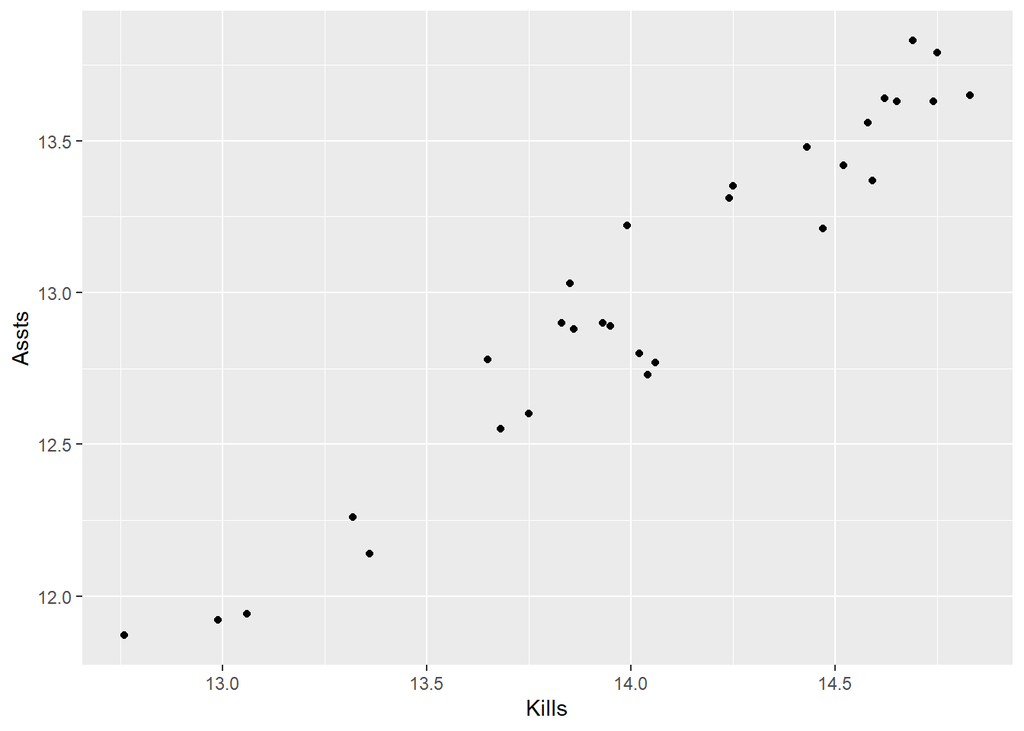

```r
ggplot(data = Volleyball2009, aes(x = Kills, y = Assts))+
  geom_point()
```

The relationship between kills and assis seems to have strong positive relation.

```r
#Using linear model with y = kills x = assts

volley_model = lm(Kills ~ Assts, data = Volleyball2009)
summary(volley_model)
```

```
##
## Call:
## lm(formula = Kills ~ Assts, data = Volleyball2009)
##
## Residuals:
##       Min        1Q    Median        3Q       Max
## -0.265426 -0.093853 -0.009895  0.092659  0.248598
##
## Coefficients:
##             Estimate Std. Error t value Pr(>|t|)
## (Intercept)  1.73626    0.60523   2.869  0.00775 **
## Assts        0.94699    0.04651  20.362  < 2e-16 ***
## ---
## Signif. codes:  0 '***' 0.001 '**' 0.01 '*' 0.05 '.' 0.1 ' ' 1
##
## Residual standard error: 0.144 on 28 degrees of freedom
## Multiple R-squared:  0.9367, Adjusted R-squared:  0.9345
## F-statistic: 414.6 on 1 and 28 DF,  p-value: < 2.2e-16
```

Based on the summary model above, the least square equation for the line is, kills = 1.74 + 0.947 * Assts. This means that for every increase in assists per set, the kills per set increase by 0.947 unit. The R^2 is 0.936 so it means that 93.6% of the variation in kills can be explained by variation in the assist per set (Assts). It also means that our model does explain a lot of( majority) of the variation in kills.

3. Calculating the residual:

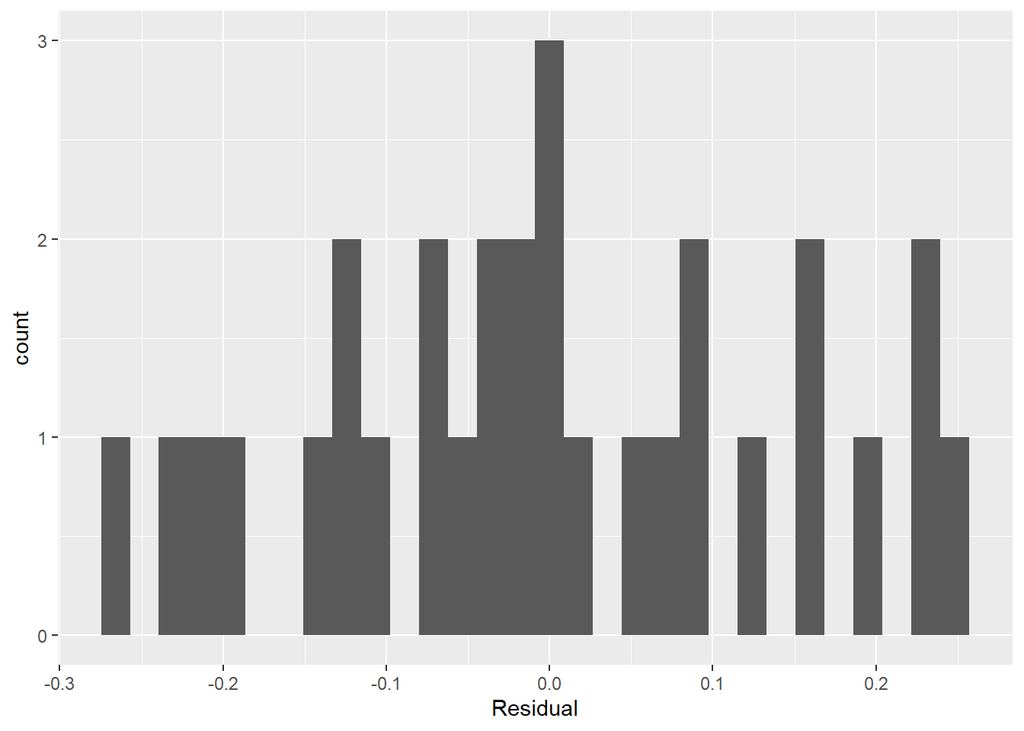

```r
volleyball_res <- tibble(residual = volley_model$residuals)
ggplot(volleyball_res, aes(x = residual)) +
  geom_histogram() +
  labs(x = "Residual")
```

From the histogram above, we can see that the residual has no specific skewness or tail. It is distributed normally and that there is no clear pattern to be alarmed about.

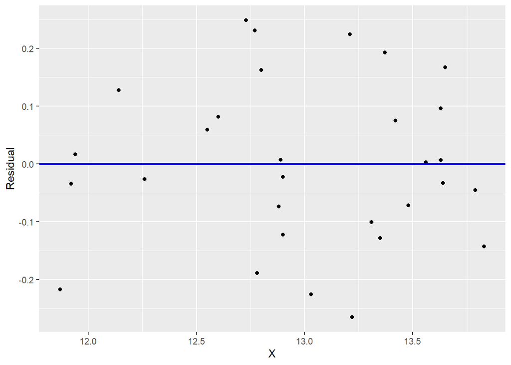

```r
nonlinear_model_data <- tibble(residual_volley = volley_model$residuals, x = Volleyball2009$Assts)
ggplot(nonlinear_model_data, aes(x = x, y = residual_volley)) +
  geom_point() +
  labs(x = "X", y = "Residual") +
  geom_hline(yintercept = 0, col = "blue", size = 1)
```

From the scatterplot above we can also see that the residual line a straight line and the plots are scattered randomnly so we donot need to worry about the appropriateness of a straight line model.

## Question 9.20

```r
df_v = nrow(Volleyball2009)
df_v
```

```
## [1] 30
```

```r
t_score_v = qt(0.975, df = df_v - 2)  #We use 2 df because we have 2 coefficients
t_score_v
```

```
## [1] 2.048407
```

```r
#From the model above;
beta = 0.94699
SD_beta = 0.04651

#So Confidence intervla is ,

upper = beta + (t_score * SD_beta)
lower  = beta - (t_score * SD_beta)

print(upper)
```

```
## [1] 1.044337
```

```r
print(lower)
```

```
## [1] 0.8496435
```

2. for Assts value of 12.4, the predicted kills and 95% confidence

```r
predict_kills = predict(volley_model, tibble(Assts =12.4), interval="confidence")
predict_kills
```

```
##       fit      lwr      upr
## 1 13.4789 13.40025 13.55754
```

For the predicted kills per game, based on the predicted model is 13.5 and the confidence interval is: (13.40, 13.56)

## Question 9.25

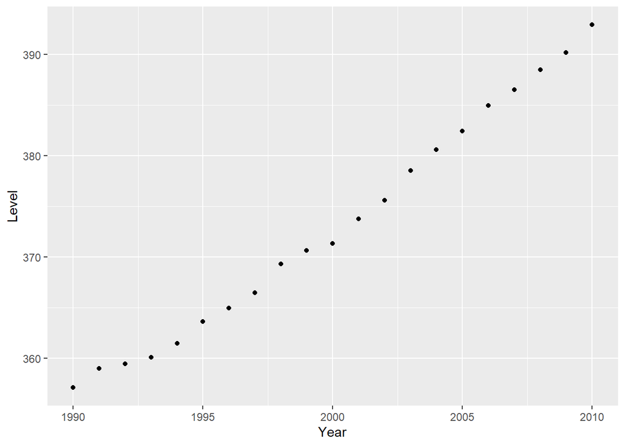

```r
#glimpse(Maunaloa)

ggplot(data = Maunaloa, aes (x = Year, y = Level))+
  geom_point()
```

The relationship seems to be linear and positively related.

```r
#Using linear model with y = C02 Level,  x = year

CO2_model = lm(Level ~ Year, data = Maunaloa)
summary(CO2_model)
```

```
##
## Call:
## lm(formula = Level ~ Year, data = Maunaloa)
##
## Residuals:
##     Min      1Q  Median      3Q     Max
## -1.8924 -0.7740 -0.1516  0.6764  2.2252
##
## Coefficients:
##               Estimate Std. Error t value Pr(>|t|)
## (Intercept) -3.280e+03  8.256e+01  -39.73   <2e-16 ***
## Year         1.826e+00  4.128e-02   44.25   <2e-16 ***
## ---
## Signif. codes:  0 '***' 0.001 '**' 0.01 '*' 0.05 '.' 0.1 ' ' 1
##
## Residual standard error: 1.145 on 19 degrees of freedom
## Multiple R-squared:  0.9904, Adjusted R-squared:  0.9899
## F-statistic:  1958 on 1 and 19 DF,  p-value: < 2.2e-16
```

From the CO2 model above, we can see that for every increase in year, the CO@ level increases by 1.826e value.

3. Residual:

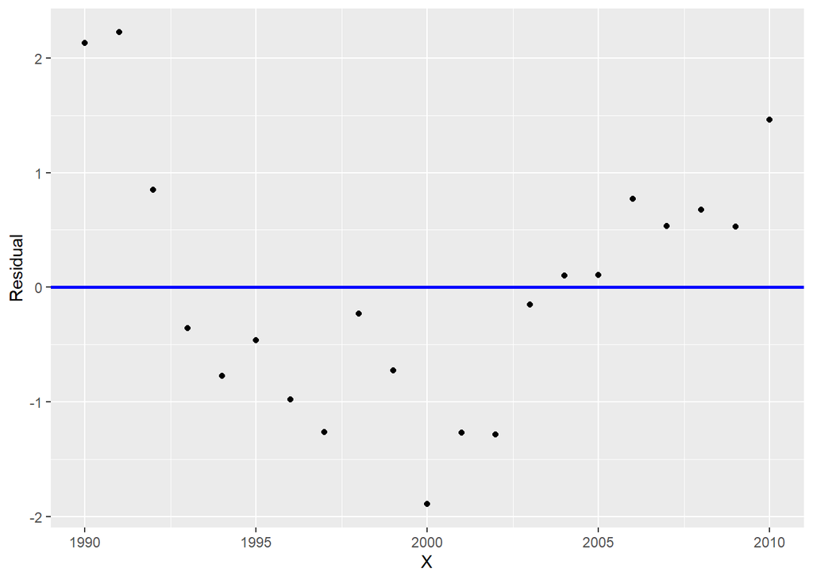

```r
Co2_residual_data <- tibble(residual_CO2 = CO2_model$residuals, x = Maunaloa$Year)
ggplot(Co2_residual_data , aes(x = x, y = residual_CO2)) +
  geom_point() +
  labs(x = "X", y = "Residual") +
  geom_hline(yintercept = 0, col = "blue", size = 1)
```

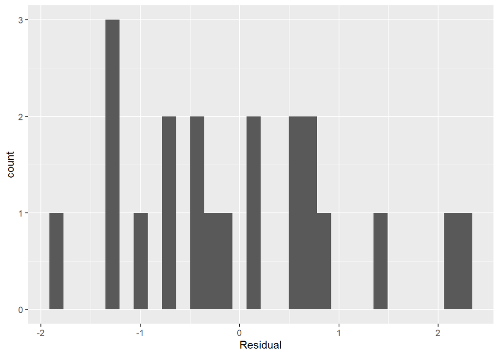

```r
CO2_res <- tibble(residual = CO2_model$residuals)
ggplot(CO2_res, aes(x = residual)) +
  geom_histogram() +
  labs(x = "Residual")
```

## Question 9.28:

```r
#glimpse(Illiteracy)

corr_illetracy = cor(Illiteracy$Illit, Illiteracy$Births,  use = "complete.obs")
corr_illetracy
```

```
## [1] 0.768663
```

The correlation between illiteracy rate and birth is 0.769. Using Bootstrap to find the 95% confidence interval:

```r
N <- 10^4
corr_illit_boot <- numeric(N)

n = nrow(Illiteracy)
for (i in 1:N)
{
  index <- sample(n, replace = TRUE)
  illit_boot <- Illiteracy[index,]
  corr_illit_boot[i] = cor(illit_boot$Illit, illit_boot$Births)
}

mean_illi <- mean(corr_illit_boot)
sd_illit <- sd(corr_illit_boot)
quantile_illit <- quantile(corr_illit_boot, c(0.025, 0.975))

mean_illi
```

```
## [1] 0.7679235
```

```r
quantile_illit
```

```
##      2.5%     97.5%
## 0.6755500 0.8423825
```

2. Permutation test to test whether illiteracy rate and births are independent:

Using coorelation for conducting permutation test to test the indepdence.

```r
N <- 10^4
n = nrow(Illiteracy)
beta_illit_corr <- numeric(N)


observed <- cor(Illiteracy$Births, Illiteracy$Illit)
for (i in 1:N)
{
  index <- sample(n, replace=FALSE)
  Illit_Boot<- Illiteracy$Births[index]
  beta_illit_corr[i] <- cor(Illit_Boot, Illiteracy$Illit)  #Maintaing same Illit and only changing the sample for Births
}

p_value_corr <- (sum(observed <= beta_illit_corr) + 1) / (N + 1) # P-value
p_value_corr
```

```
## [1] 9.999e-05
```

The p value is really small ( less than 0.05), so the probability of random chance alone producing the correlation 0.769 is really low so we can reject the null hypothesis that they are independent. SO, we conclude that birth and illiteracy are not independent.

## Question 9.40

1. Logistics equation for male passengers on Titanic Data only has make, survived = 1 if the passenger survived.

```r
glimpse(Titanic)
```

```
## Rows: 658
## Columns: 3
## $ ID       <int> 1, 2, 3, 4, 5, 6, 7, 8, 9, 10, 11, 12, 13, 14, 15, 16, 17, 18…
## $ Survived <int> 1, 0, 1, 0, 0, 0, 1, 0, 0, 1, 1, 0, 1, 1, 0, 1, 0, 0, 0, 0, 1…
## $ Age      <dbl> 0.92, 30.00, 48.00, 39.00, 71.00, 47.00, 80.00, 24.00, 36.00,…
```

```r
titanic_male_model <- glm( Survived ~ Age, data=Titanic, family=binomial)  #Binomial because it is a 1,0 value within the logistic regression
summary(titanic_male_model)
```

```
##
## Call:
## glm(formula = Survived ~ Age, family = binomial, data = Titanic)
##
## Deviance Residuals:
##     Min       1Q   Median       3Q      Max
## -0.9096  -0.7158  -0.6472  -0.4961   2.2960
##
## Coefficients:
##              Estimate Std. Error z value Pr(>|z|)
## (Intercept) -0.660761   0.224807  -2.939  0.00329 **
## Age         -0.023760   0.007276  -3.266  0.00109 **
## ---
## Signif. codes:  0 '***' 0.001 '**' 0.01 '*' 0.05 '.' 0.1 ' ' 1
##
## (Dispersion parameter for binomial family taken to be 1)
##
##     Null deviance: 667.85  on 657  degrees of freedom
## Residual deviance: 656.56  on 656  degrees of freedom
## AIC: 660.56
##
## Number of Fisher Scoring iterations: 4
```

So, the coefficient is 0.0237. The likelihood of survival decreases by 0.024 odds as the age increases.

2. Comparing the odds of survival for 30 and 40:

```r
f <- function(x)
{
  return(odds_surv <- exp(-0.661 - (0.0234*x))/(1 + exp(-0.661 - (0.0234 *x))))    #Using formula for calculations:
}



age_30 <- f(30)
age_30
```

```
## [1] 0.2037532
```

```r
age_40 <- f(40)
age_40
```

```
## [1] 0.1684013
```

```r
#odds_surv <- exp(-0.661 - (-0.0234x))/(1 + exp(-0.661 - (-0.0234x))
```

3. bootstrap interval for slope:

```r
N <- 10^4
n <-nrow(Titanic)
beta_boot <- numeric(N)

for (i in 1:N)
{
  index <- sample(n, replace = TRUE)
  titanic_boot <- Titanic[index, ]
  titanic_boot_model <- glm( Survived ~ Age, data=titanic_boot, family=binomial)
  beta_boot[i] <- coef(titanic_boot_model)[2]

}

slope_bootrange <- quantile(beta_boot, c(0.025, 0.975))
slope_bootrange
```

```
##         2.5%        97.5%
## -0.039910822 -0.008412462
```

4. calculate the probability of 69 year old man surviving and find a 95% bootstrap percentile interval:

```r
#Prediction for 69 year old man surviving:

predict_69 <- predict(titanic_male_model, tibble(Age= 69), type = "response")
predict_69
```

```
##          1
## 0.09110687
```

So, the probability of a 69 year old man surviving is 9.11%

Now, the bootstrap:

```r
N <- 10^4
n <- nrow(Titanic)
predict_boot <- numeric(N)

for (i in 1:N)
{
  index <- sample(n, replace = TRUE)
  titanic_m_boot <- Titanic[index, ]
  male_boot <- glm( Survived ~ Age, data=titanic_m_boot, family=binomial)
  predict_boot[i] = predict(male_boot, tibble(Age = 69), type = "response")

}

age_69_boot <- quantile(predict_boot, c(0.025, 0.975))
age_69_boot
```

```
##       2.5%      97.5%
## 0.04564744 0.15857084
```